# Weekly Sales Forecast for Big Box, Inc.

Big Box, Inc. requested a forecast of weekly sales for the individual deparments in each of its stores. The company provided the data team with three CSV files containing data related to its stores and their departments, weekly sales, and economic and weather conditions in the geographic areas where stores are located. Specifically Big Box requested a forecast of the next three months beyond the actual sales data provided.

We performed a time series analysis through the following phases:

# Time Series Analysis Phases

1. [Data Import, Validation, and Merge](https://mstuartproj.github.io/sales_forecast/Sales_Forecast_1.html)
2. [Exploratory Data Analysis: Stores, Departments, and Total Sales](https://mstuartproj.github.io/sales_forecast/Sales_Forecast_2.html)
3. [Exploratory Data Analysis: Weekly Sales](https://mstuartproj.github.io/sales_forecast/Sales_Forecast_3.html)
4. [Feature Creation and Selection](https://mstuartproj.github.io/sales_forecast/Sales_Forecast_4.html)
5. [Modeling and Prediction: Random Forest Regression](https://mstuartproj.github.io/sales_forecast/Sales_Forecast_5.html)
6. [Modeling and Prediction: SARIMA](https://mstuartproj.github.io/sales_forecast/Sales_Forecast_6.html)

[figure not shown]

# Phase 6. Modeling and Prediction: SARIMA

Modeling was performed using statsmodels' method for seasonal autoregressive integrated moving average (SARIMA). This method is appropriate for time series data that has a seasonal component. Some departments in the company's stores have seasonal sales. Of the provided data, the SARIMA model only used dates and weekly sales. It does not use any other features such as store size and type, unemployment, temperature. etc. This model predicts one department's sales at a time.

## Decomposition of a Seasonal Data Set

Below are the details of the analysis for **Store 1 Department 3** which has a seasonal component. We graphed this department's weekly sales and noted high peaks in late August of each year. We also decomposed the sales data and noted what might be a very small upward trend in sales. However we clearly see a strong seasonal component.

[figure not shown]

```python
import sys
import warnings
import matplotlib.pyplot as plt
import matplotlib.ticker as tick
import numpy as np
import pandas as pd
import itertools
from itertools import product
import statsmodels.api as sm
from statsmodels.tsa.seasonal import seasonal_decompose
from sklearn.metrics import mean_absolute_error
from sklearn.metrics import mean_squared_error
from sklearn.metrics import r2_score
```

```python
#Read in the full data set for the entire range of weeks
fulldata = pd.read_csv('data_merged/fulldataset.csv',
                       index_col = 0)
fulldata.head()
```

|  | Store | Dept | Date | Weekly_Sales | IsHoliday | Type | Size | Temperature | Fuel_Price | MarkDown1 | MarkDown2 | MarkDown3 | MarkDown4 | MarkDown5 | CPI | Unemployment |
| --- | --- | --- | --- | --- | --- | --- | --- | --- | --- | --- | --- | --- | --- | --- | --- | --- |
| 0 | 1 | 1 | 2010-02-05 | 24924.50 | False | A | 151315 | 42.31 | 2.572 | NaN | NaN | NaN | NaN | NaN | 211.096358 | 8.106 |
| 1 | 1 | 1 | 2010-02-12 | 46039.49 | True | A | 151315 | 38.51 | 2.548 | NaN | NaN | NaN | NaN | NaN | 211.242170 | 8.106 |
| 2 | 1 | 1 | 2010-02-19 | 41595.55 | False | A | 151315 | 39.93 | 2.514 | NaN | NaN | NaN | NaN | NaN | 211.289143 | 8.106 |
| 3 | 1 | 1 | 2010-02-26 | 19403.54 | False | A | 151315 | 46.63 | 2.561 | NaN | NaN | NaN | NaN | NaN | 211.319643 | 8.106 |
| 4 | 1 | 1 | 2010-03-05 | 21827.90 | False | A | 151315 | 46.50 | 2.625 | NaN | NaN | NaN | NaN | NaN | 211.350143 | 8.106 |

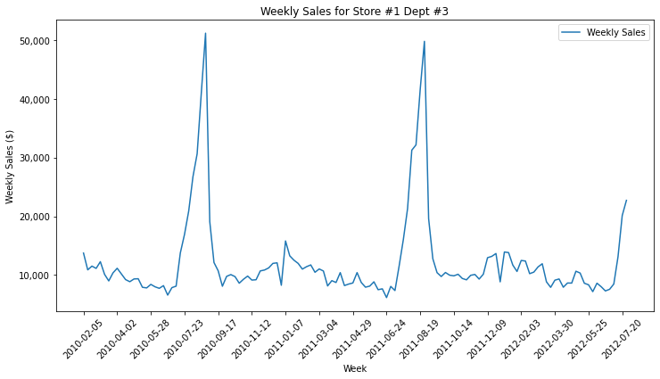

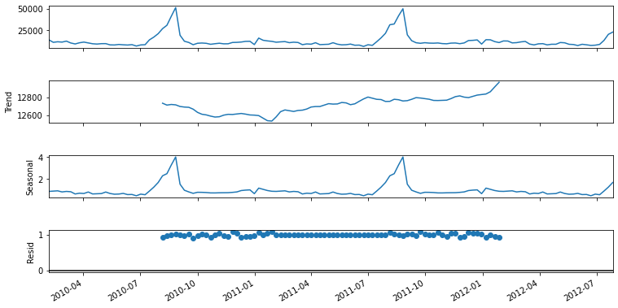

```python
#Run Store 1 Department 3
onestorenum = 1
onedeptnum = 3

onestoredata = fulldata.copy(deep=True)
onestoredata = onestoredata.loc[onestoredata['Store'] == onestorenum]
onedeptdata = onestoredata.loc[onestoredata['Dept'] == onedeptnum]

#Only need the dates and weekly sales
onedept_set = onedeptdata.filter(['Date','Weekly_Sales'], axis=1)
#Use the dates as the index
onedept_set.set_index('Date', inplace=True)
#The dates need to be DateTime objects
onedept_set.index = pd.to_datetime(onedept_set.index)

#Visualize the decomposition of the data set
plt.figure(figsize=(12, 6))
plt.xlabel('Week')
plt.ylabel('Weekly Sales ($)')
plt.title('Weekly Sales for Store #' + str(onestorenum) +
              " Dept #" + str(onedeptnum))
plt.xticks(np.arange(0, len(onedept_set)+1, 8))
plt.xticks(rotation=45)
plt.plot(onedeptdata['Date'],
         onedeptdata['Weekly_Sales'],
         label='Weekly Sales')
plt.legend()
ax = plt.gca()
ax.yaxis.set_major_formatter(tick.FuncFormatter(lambda x, p: format(int(x), ',')));

seasonal_decomp = seasonal_decompose(onedept_set, model='multiplicative')
fig = seasonal_decomp.plot()
fig.set_size_inches(12,6)
fig.autofmt_xdate()
```

[figure not shown]

## Finding the Best SARIMA Model

SARIMA models are denoted by three parameters known as p, d, and q. To find the best model to predict sales for **Store 1 Department 3**, we fit one model for every combination of the (p, d, q) triplet and then we selected the model with the lowest AIC. The Akaike information criterion (AIC) is a measure of model fit and a lower AIC is better. This was the model chosen:

- Order = (1, 0, 0)
- Seasonal_Order = (1, 0, 0, 52)
- AIC = 92.7255

[figure not shown]

```python
# Define the p, d and q parameters to take any value between 0 and 3
p = d = q = range(0, 2)
# Generate all different combinations of p, d and q triplets
pdq = list(itertools.product(p, d, q))
# Generate all different combinations of seasonal p, d and q triplets
seasonal_pdq = [(x[0], x[1], x[2], 52) for x in list(itertools.product(p, d, q))]
# Print out some of the parameter combinations
print('Examples of parameter combinations for Seasonal ARIMA: ')
print('SARIMAX: {} x {}'.format(pdq[1], seasonal_pdq[0]))
print('SARIMAX: {} x {}'.format(pdq[1], seasonal_pdq[1]))
print('SARIMAX: {} x {}'.format(pdq[1], seasonal_pdq[2]))
print('.....')
print('SARIMAX: {} x {}'.format(pdq[2], seasonal_pdq[0]))
print('SARIMAX: {} x {}'.format(pdq[2], seasonal_pdq[1]))
print('SARIMAX: {} x {}'.format(pdq[2], seasonal_pdq[2]))
print('.....')
print('SARIMAX: {} x {}'.format(pdq[7], seasonal_pdq[5]))
print('SARIMAX: {} x {}'.format(pdq[7], seasonal_pdq[6]))
print('SARIMAX: {} x {}'.format(pdq[7], seasonal_pdq[7]))
```

```
Examples of parameter combinations for Seasonal ARIMA:
SARIMAX: (0, 0, 1) x (0, 0, 0, 52)
SARIMAX: (0, 0, 1) x (0, 0, 1, 52)
SARIMAX: (0, 0, 1) x (0, 1, 0, 52)
.....
SARIMAX: (0, 1, 0) x (0, 0, 0, 52)
SARIMAX: (0, 1, 0) x (0, 0, 1, 52)
SARIMAX: (0, 1, 0) x (0, 1, 0, 52)
.....
SARIMAX: (1, 1, 1) x (1, 0, 1, 52)
SARIMAX: (1, 1, 1) x (1, 1, 0, 52)
SARIMAX: (1, 1, 1) x (1, 1, 1, 52)
```

```python
# Generate AIC scores for the p,d,q combinations
warnings.filterwarnings("ignore") # specify to ignore warning messages
list_AIC = pd.DataFrame({}, columns=['param','param_seasonal','AIC'])

for param in pdq:
    for param_seasonal in seasonal_pdq:
        try:
            mod = sm.tsa.statespace.SARIMAX(onedept_set,
                                            #trend='c',
                                            order=param,
                                            seasonal_order=param_seasonal)
            results = mod.fit()

            #Save the AICs so we can easily find the minimum
            temp = pd.DataFrame([[param, param_seasonal, results.aic ]],
                                columns=['param','param_seasonal','AIC'])
            list_AIC = list_AIC.append(temp, ignore_index=True)

        except Exception as e:
            sys.stdout.write('Exception: ' + str(e))
            sys.stdout.flush()
            continue
```

```python
#Print out the minimum aic from all the AICs we collected
min_val = np.amin(list_AIC['AIC'].values) # Find minimum value in AIC
loc_min_val = list_AIC['AIC'].tolist().index(min_val) # Find index number for lowest AIC
min_AIC = list_AIC.iloc[loc_min_val,:]
print("### Mininum AIC is ### \n{}".format(min_AIC))
```

```
### Mininum AIC is ###
param                 (1, 0, 0)
param_seasonal    (1, 0, 0, 52)
AIC                     92.7255
Name: 36, dtype: object
```

[figure not shown]

## Model Fitting and Evaluation

We split our data set into a training set, which contained 80% of the data, and a validation set which contained the remaining 20%. The training set contained sales through the end of January 2012, while the validation set contained sales beyond January 2012. We fit our best model and then used the model to predict sales for the dates in the validation set.

> NOTE: The data was split differently (using a different date) for this SARIMA analysis than how it was split for Random Forest Regression. Therefore the metrics below cannot be directly compared to the Random Forest Regression metrics.

Fitting the model and generating predictions produced the following metrics. The RMSE of 1615 is 15.5% of the average actual sales of $10,401 for **Store 1 Department 3's**. Future effort can attempt to fine tune the model to decrease the RMSE.

- Mean Squared Error (MSE) = 2608873
- Root Mean Square Error (RMSE) = 1615
- Mean Absolute Error (MAE) = 1306

We created a function to plot predicted versus actual weekly sales. We created one plot to compare the predictions against the validation set. Then we created a second plot to visualize the predictions with the entire range of available dates.

[figure not shown]

```python
#Split the data into training/test sets where the training set
#has 80% (79.9%) of the rows
#Training start date is 2010-02-05
#Training end date is 2012-01-31
train_set = onedept_set.loc[:'2012-01-31']
test_set = onedept_set.loc['2012-01-31':]

#Fit the chosen model on the training set
mod = sm.tsa.statespace.SARIMAX(train_set,
                                #trend='c',
                                order=(1,0,0),
                                seasonal_order=(1,0,0,52))
model_fit = mod.fit()
forecast = model_fit.forecast(steps=len(test_set))
```

```python
#Calculate performance metrics
forecast_set = pd.DataFrame(forecast)
metric_mean_sqr_err = mean_squared_error(test_set, forecast_set)
metric_root_mean_sqr_err = np.sqrt(mean_squared_error(test_set, forecast_set))
metric_mean_abs_err = mean_absolute_error(test_set, forecast_set)
metric_r2_score = r2_score(test_set, forecast_set)

print('### Performance Metrics for Store ' + str(onestorenum)
     + ' Dept ' + str(onedeptnum) + " ###")
print('Mean Squared Error (MSE)= ' + "{:.0f}".format(metric_mean_sqr_err))
print('Root Mean Square Error (RMSE) = ' + "{:.0f}".format(metric_root_mean_sqr_err))
print('Mean Absolute Error (MAE) = ' + "{:.0f}".format(metric_mean_abs_err))
```

```
### Performance Metrics for Store 1 Dept 3 ###
Mean Squared Error (MSE)= 2608873
Root Mean Square Error (RMSE) = 1615
Mean Absolute Error (MAE) = 1306
```

```python
#Function to plot predicted vs actual weekly sales
#for one deparment in one store
def plot_pred_vs_actual_sales(actualdates,
                              actualsales,
                              preddates,
                              predsales,
                              storenum,
                              deptnum,
                              x_date_spacing=1):
    plt.figure(figsize=(10, 5))
    plt.xlabel('Week')
    plt.ylabel('Weekly Sales ($)')
    plt.title('Actual and Predicted Weekly Sales for Store #' + str(storenum) +
              " Dept #" + str(deptnum))
    plt.xticks(np.arange(0, len(actualsales)+1, x_date_spacing))
    plt.xticks(rotation=45)
    plt.plot(actualdates,
             actualsales,
             label='Actual Weekly Sales')
    plt.plot(preddates,
             predsales,
             label='Predicted Weekly Sales', color='magenta')
    plt.legend()
    ax = plt.gca()
    ax.yaxis.set_major_formatter(tick.FuncFormatter(lambda x, p: format(int(x), ',')));
```

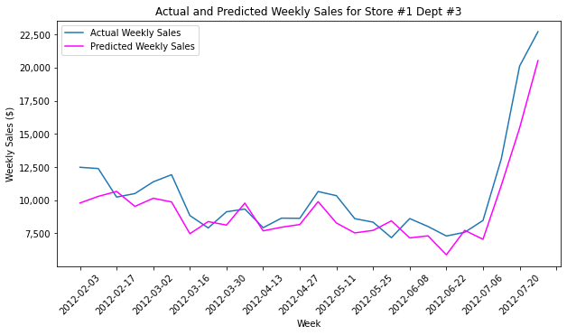

```python
#Plot the forecasted sales against the test set sales
testdates = pd.DataFrame(test_set.index)
testdates['Date'] = testdates['Date'].astype(str)
predicteddata = pd.DataFrame(forecast_set)
plot_pred_vs_actual_sales(testdates['Date'],
                          test_set['Weekly_Sales'],
                          testdates['Date'],
                          predicteddata['predicted_mean'],
                          onestorenum,
                          onedeptnum,
                          x_date_spacing=2)
```

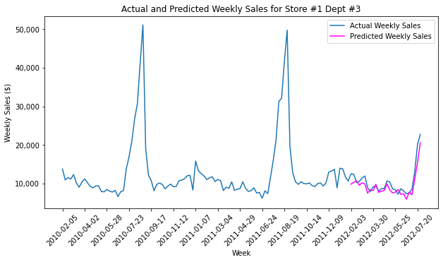

```python
#Plot the forecasted sales against the entire weekly sales
alldates = pd.DataFrame(onedept_set.index)
alldates['Date'] = alldates['Date'].astype(str)
predicteddata = pd.DataFrame(forecast_set)
plot_pred_vs_actual_sales(alldates['Date'],
                          onedept_set['Weekly_Sales'],
                          testdates['Date'],
                          predicteddata['predicted_mean'],
                          onestorenum,
                          onedeptnum,
                          x_date_spacing=8)
```

[figure not shown]

## Model Fitting and Evaluation (Another Department)

We repeated the same steps with a different department, **Store 33 Department 80**. We first graphed this department's weekly sales and decomposed the data to see trend and seasonal components. Sales do not appear to be seasonal, however there is a clear decreasing trend.

We found the best model with the lowest AIC, then we fit the model and used it to generate predictions. The metrics are listed below. The RMSE of 1245 is 17.5% of the average actual sales of $7,093 for **Store 33 Department 80**. Future effort can attempt to fine tune the model to decrease the RMSE.

- Mean Squared Error (MSE) = 1549237
- Root Mean Square Error (RMSE) = 1245
- Mean Absolute Error (MAE) = 1159

We noted that the predictions are higher than the actual sales. Removing the down trend from the data and then fitting the model again may improve predictions.

[figure not shown]